# Outcomes after Subacromial Balloon Spacer Implantation for Massive and Irreparable Rotator Cuff Tears - A Systematic Review and Meta-Analysis

Kennedy Gachigi - Research Scientist

2023-02-23

# Introduction

How do surgeons know if a new type of surgery is viable or not?

They can ask their study team to perform a meta-analysis! A method for systematically combining pertinent qualitative and quantitative study data from several selected studies to develop a single conclusion that has greater statistical power.

one of the latest considerations by OrthoCarolina orthopedic surgeons is the management of massive and irreparable rotator cuff tears (RCTs). Currently, there is no consensus regarding the gold standard treatment, however, an emerging option involves the use of a biodegradable spacer placed in the subacromial space.

The purpose of this study, therefore, was to systematically review and synthesize the current literature reporting on the outcomes and complications of patients undergoing implantation of a subacromial balloon (SAB) spacer for the treatment of massive and irreparable RCTs.

# Methods

A systematic review of the PubMed Central, MEDLINE, Embase, Scopus, and Cochrane Library databases from inception through December 2022 was performed. Clinical outcomes studies reporting on functional and clinical outcomes, as well as postoperative complications, were included.

# Patient reported outcomes (PROs)

## Constant score

The Constant score is designed to assess shoulder disorders in general by combining subjective and objective measurements such as pain (15 points), activities of daily living (20 points), strength (25 points) and the range of motion (40 points). Total point = 100, the higher the score the better the shoulder functionality.

Ten studies reported a measure of variance in addition to pre- and postoperative scores and were eligible for inclusion in the quantitative synthesis.

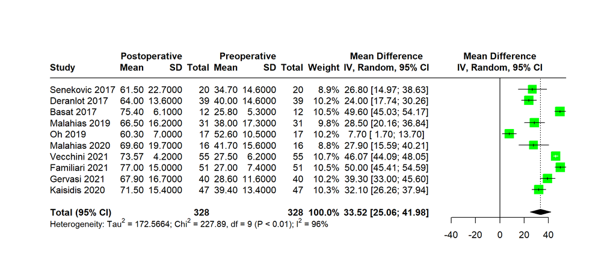

Meta-analysis revealed a significant improvement in Constant scores with a mean increase of 33.5.

What can we infer about the similarity of these studies?

The high I-squared reveals a very low degree of homogeneity(similar) and consequently a high degree of heterogeneity meaning that there is a lot of variation between the studies. Nevertheless, a surgeon who chooses to perform this surgery should expect an improvement in the constant score of between 25-42. (Confidence interval)

## American Shoulder and Elbow Surgeons score (ASES)

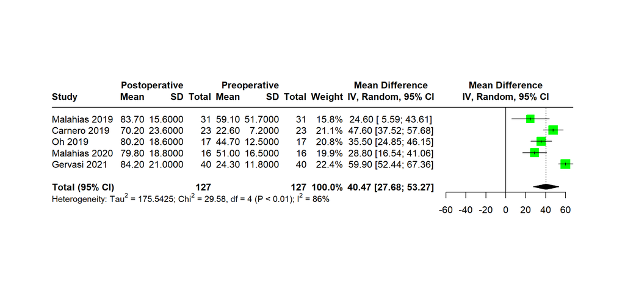

## Oxford Shoulder score (OSS)

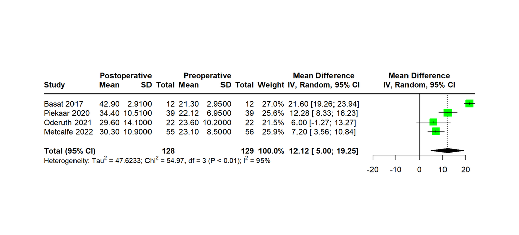

[figure not shown]

## Forward Elevation (degrees)

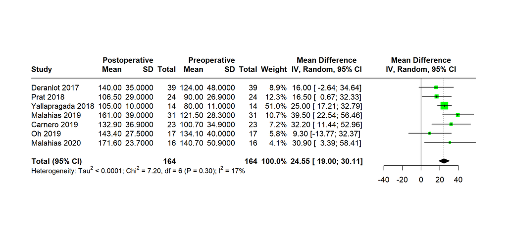

## Abduction (degrees)

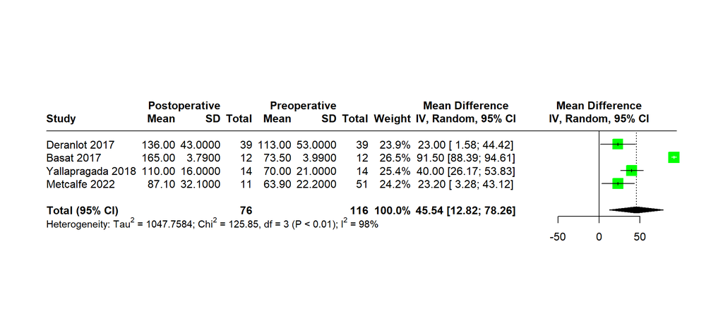

## External Rotation (degrees)

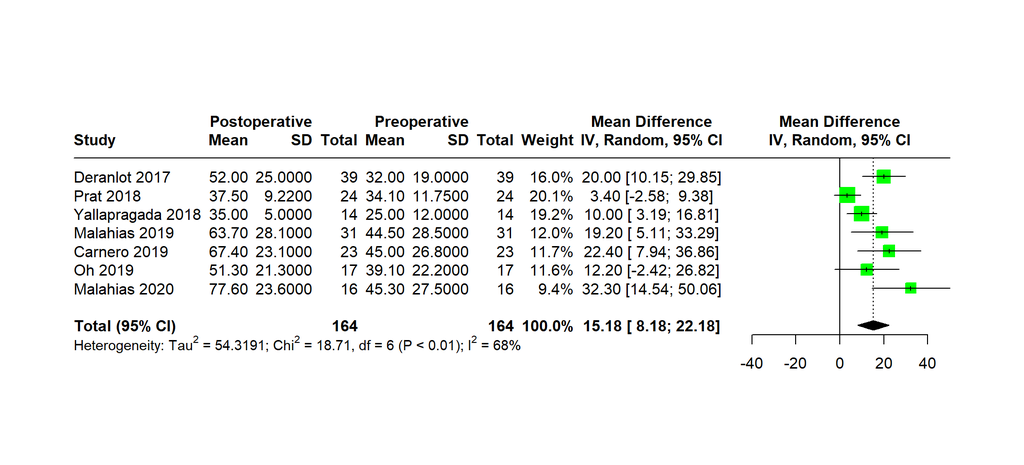

# Conclusion

[figure not shown]

# Paw corner

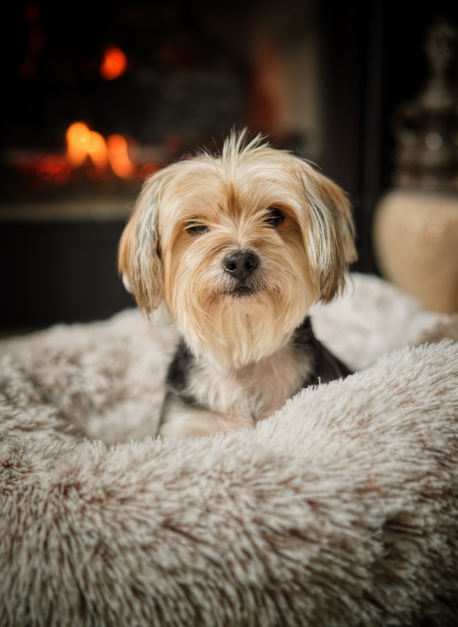

**Its the end of a great Baxter week!**